# Unit 2: Types of Data

Getting to Know Your Data

Anil

## Why “Get to Know Your Data” First?

> “It’s tempting to jump straight into mining, but first, we need to get the data ready.”

Real-world data is:

- **Noisy** — errors, typos, sensor glitches
- **Enormous** — gigabytes to petabytes
- **Heterogeneous** — pulled from many different sources

Before you can clean, integrate, or mine data, you must know **what kind of data you have** and **what its numbers actually mean**.

## Questions

1. What **type** is each attribute — nominal, binary, ordinal, or numeric?
2. What are the **central tendency** and **spread** of each attribute’s values?
3. How can I **visualize** an attribute to spot patterns and outliers?
4. How do I measure **similarity/dissimilarity** between data objects?

# Part 1: Data Objects & Attribute Types

## Data Objects and Attributes

- A **data object** = one entity (a row): a customer, a patient, a student, a transaction
- Also called: *sample, example, instance, data point, tuple*
- An **attribute** = one characteristic of that object (a column)
- Also called: *dimension* (data warehousing), *feature* (machine learning), *variable* (statistics)

```
                attribute →   customer_id | age | income | city
data object →         row:      C001      |  22 |  45000 | Pune
```

## Example — Objects & Attributes in Your Own Data

| Domain | Data object | Example attributes |
| --- | --- | --- |
| E-commerce | one order | order_id, price, quantity, category |
| College ERP | one student | roll_no, cgpa, branch, attendance |
| Banking | one transaction | txn_id, amount, type, timestamp |
| Healthcare | one patient | patient_id, blood_group, bp, diagnosis |

**Every dataset will be row/column model.**

## Types of Data

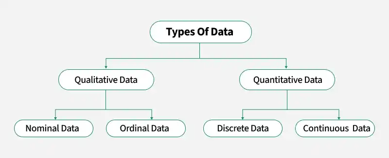

Types of Data

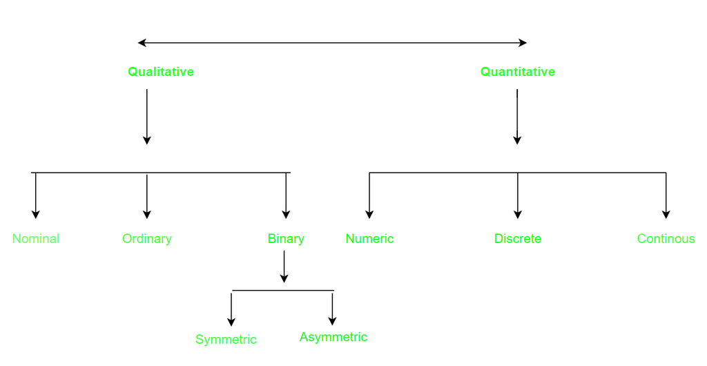

## Types of Data

https://www.youtube.com/watch?v=pZ5LE9p0D7Y

## The Four Attribute Types — Overview

| Type | Meaningful order? | Meaningful magnitude/distance? | Example |
| --- | --- | --- | --- |
| **Nominal** | ❌ No | ❌ No | hair color, city |
| **Binary** | ❌ No | ❌ No | Gender (0/1) |
| **Ordinal** | ✔️ Yes | ❌ No | water bottle size (S/M/L) |
| **Numeric** | ✔️ Yes | ✔️ Yes | age, income, temperature |

This table determines **which statistics and which mining algorithms are even valid** for a given column.

## Nominal Attributes

- Values are **symbols/names** — categories, codes, or states
- **No meaningful order**
- Even if stored as numbers (e.g., `0` = black hair, `1` = brown), **you cannot do math on them**

```
hair_color ∈ {black, brown, blond, red, auburn, gray, white}
marital_status ∈ {single, married, divorced, widowed}
```

**Valid statistic:** mode only (most frequent value). Mean/median are meaningless.

## 🏭 Industry Example — Nominal Attributes

| Platform | Nominal attribute | Values |
| --- | --- | --- |
| **Flipkart / Amazon** | `product_category` | Electronics, Fashion, Grocery… |
| **Swiggy / Zomato** | `restaurant_cuisine` | North Indian, Chinese, Italian… |
| **Naukri / LinkedIn** | `job_function` | Engineering, Sales, HR… |
| **Banking (KYC)** | `account_type` | Savings, Current, NRI |

```r
# Computing "average product_category" is meaningless — only mode makes sense
df <- data.frame(product_category = c("Electronics", "Fashion", "Electronics", "Grocery"))
Mode <- function(x) {
  ux <- unique(x)
  ux[which.max(tabulate(match(x, ux)))]
}
Mode(df$product_category)  # ✔️ valid
```

```
## [1] "Electronics"
```

```r
# mean(df$product_category) # ❌ throws an error / nonsensical
```

## Binary Attributes

A nominal attribute with **only two states**: `0` or `1` (present/absent)

- **Symmetric binary:** both outcomes equally important, no preferred “1”
  - e.g., `gender` (male/female) — neither state is inherently more significant
- **Asymmetric binary:** outcomes are *not* equally important — rarer/more important one coded as `1`
  - e.g., `HIV_test` — positive (1) matters far more than negative (0)

## 🏭 Industry Example — Symmetric vs. Asymmetric Binary

| Attribute | Type | Why |
| --- | --- | --- |
| `is_weekend` (order placed on weekend?) | Symmetric | Yes/No equally “normal” |
| `is_fraud` (credit card transaction) | **Asymmetric** | Fraud (1) is rare & far more important than legitimate (0) |
| `clicked_ad` (0/1) | **Asymmetric** | A click is rare and the signal you actually care about |
| `has_backlog` (student record) | **Asymmetric** | “Has a backlog” (1) is the meaningful, rarer state |

**Why it matters:** similarity/distance measures (Ch. 2.4) treat symmetric and asymmetric binary attributes *differently* — getting this wrong silently breaks clustering and recommendation algorithms.

## Ordinal Attributes

- Values have a **meaningful order**, but the **gap between values is unknown**

```
drink_size ∈ {small, medium, large}      # order known, exact size-gap unknown
grade      ∈ {A+, A, A–, B+, B, B–, ...}
```

- Great for **subjective ratings** in surveys:

```
satisfaction ∈ {0: very dissatisfied, 1: somewhat dissatisfied,
                 2: neutral, 3: satisfied, 4: very satisfied}
```

**Valid statistics:** mode **and** median. ❌ Mean is *not* mathematically defined (though often computed loosely in practice — a common real-world misuse!).

## 🏭 Industry Example — Ordinal Attributes

| Platform | Ordinal attribute |
| --- | --- |
| **Amazon / Flipkart reviews** | ⭐ star rating (1–5) |
| **Swiggy / Zomato** | delivery experience: Poor / Average / Good / Excellent |
| **Naukri** | candidate seniority: Fresher / Junior / Mid / Senior / Lead |
| **NIRF / QS Rankings** | college rank tier (not a true numeric distance) |

```r
# Star ratings are ordinal — median is meaningful, but be careful with mean:
ratings <- c(4, 5, 3, 4, 2, 5, 4, 3, 4, 5)
median(ratings)   # ✔️ statistically sound
```

```
## [1] 4
```

```r
mean(ratings)     # ⚠️ extremely common in industry, but technically an abuse
```

```
## [1] 3.9
```

```r
                  #    of an ordinal scale — discuss with students!
```

## Numeric Attributes: Interval-Scaled

- **Quantitative**, measured in equal-size units
- Has order **and** meaningful differences
- **No true zero point** → cannot form meaningful *ratios*

```
temperature (°C):  20°C is 5° warmer than 15°C   ✔️ valid difference
                   "20°C is twice as hot as 10°C" ❌ invalid — no true zero!
calendar_year:     2024 − 2016 = 8 years apart    ✔️ valid difference
                   "year 2024 is twice year 1012" ❌ meaningless
```

**Valid statistics:** mean, median, mode — all valid.

## Numeric Attributes: Ratio-Scaled

- Same as interval-scaled, **plus a true zero point**
- Ratios ARE meaningful

```
weight, height, age, salary, count of items
₹100 is genuinely 100× richer than ₹1   ✔️
0 kg truly means "no weight"            ✔️ true zero
```

**Rule of thumb:** if `0` means “none of this exists,” it’s ratio-scaled. If `0` is just an arbitrary reference point, it’s interval-scaled.

## 🏭 Industry Example — Interval vs. Ratio in Real Datasets

| Attribute | Type | Why |
| --- | --- | --- |
| `order_amount` (₹) | **Ratio** | ₹0 = no purchase; ₹2000 is genuinely 2× ₹1000 |
| `temperature_sensor` (°C, IoT device) | **Interval** | 0°C isn’t “no temperature” |
| `credit_score` (300–850) | Interval-ish | No true zero; differences matter, ratios don’t |
| `years_of_experience` | **Ratio** | 0 years = genuinely no experience; 10 yrs = 2× 5 yrs |
| `date_of_joining` (as a raw date) | **Interval** | “2020 is not twice 1010” |

**Practical impact:** feeding an interval-scaled attribute into a ratio-based computation (like “% change”) silently produces garbage — a very common real bug.

## Discrete vs. Continuous Attributes

|  | Discrete | Continuous |
| --- | --- | --- |
| **Definition** | Finite / countably infinite set of values | Infinite possible values (within a range) |
| **Examples** | age (0–110 as integers), pincode, `is_fraud` | height, temperature, GPA (as a real number) |
| **Note** | Nominal, binary & ordinal are always discrete | Numeric attributes are *usually* continuous |

```r
df <- data.frame(pincode = c(110001, 110002, 110001, 110003), height_cm=c(100,150, 160, 200))
length(unique(df$pincode))   # discrete — finite, countable set
```

```
## [1] 3
```

```r
summary(df$height_cm)        # continuous — represented as numerics
```

```
##    Min. 1st Qu.  Median    Mean 3rd Qu.    Max.
##   100.0   137.5   155.0   152.5   170.0   200.0
```

## 🎯 Practical Example — Classify Every Column Yourself

**Dataset:** a college placement dataset.

| Column | Type? |
| --- | --- |
| `branch` (CSE, ECE, ME…) | ? |
| `placed` (Yes/No) | ? |
| `interview_rounds_cleared` (0,1,2,3) | ? |
| `package_lpa` (e.g., 6.5) | ? |
| `satisfaction_rating` (Poor/Avg/Good) | ? |

*(Answers: nominal, asymmetric binary, ratio/discrete, ratio/continuous, ordinal — discuss as a class!)*

# Part 2: Basic Statistical Descriptions — Central Tendency

## Measures of Central Tendency

Given values $x_1, x_2, \dots, x_N$ for an attribute $X$ — **where do most values fall?**

| Measure | Formula / definition | Works for |
| --- | --- | --- |
| **Mean** | $\bar{x} = \frac{\sum x_i}{N}$ | Numeric only |
| **Median** | middle value when sorted | Numeric & ordinal |
| **Mode** | most frequent value | All types |
| **Midrange** | $\frac{\min + \max}{2}$ | Numeric only |

## Example — Mean (R)

**Salary data (in ₹1000s), sorted:** 30, 36, 47, 50, 52, 52, 56, 60, 63, 70, 70, 110

```r
salary <- c(30,36,47,50,52,52,56,60,63,70,70,110)
mean(salary)
```

```
## [1] 58
```

```r
# → 58.0
```

$$\bar{x} = \frac{30+36+\dots+110}{12} =
\frac{696}{12} = 58 \Rightarrow \textbf{₹58,000}$$

⚠️ Notice `110` is far from the rest — a hint the mean might be misleading here.

## 🎯 Practical Example — The Mean Can Lie

**Scenario:** average salary at a 10-person startup.

```r
salaries <- c(4,4.2,4.5,4.5,4.8,5,5,5.2,5.5,60)   # in ₹ lakhs; last = founder/CEO
mean(salaries)
```

```
## [1] 10.27
```

```r
# → 10.27 lakhs  ← "average employee earns ₹10.27L"??
```

**Fix — trimmed mean:** drop the top/bottom 2–10% before averaging.

```r
trimmed <- sort(salaries)[2:9]   # drop 1 highest & 1 lowest
mean(trimmed)                    # a far more honest "typical" salary
```

```
## [1] 4.8375
```

## Weighted Mean

When some values matter more (occur more often, carry more importance):

$$\bar{x} = \frac{\sum w_i x_i}{\sum
w_i}$$

## 🏭 Industry Example — Weighted Average Rating (R)

```r
# Product review score, weighted by number of reviews per star
stars   <- c(5, 4, 3, 2, 1)
counts  <- c(820, 340, 90, 40, 60)   # number of reviewers giving that rating

weighted_avg <- sum(stars * counts) / sum(counts)
print(weighted_avg)   # → 4.35 ⭐
```

```
## [1] 4.348148
```

This is exactly how Amazon/Flipkart compute the “4.3 ★” summary shown on a product page.

## Example — Median (R)

Same salary data, N = 12 (**even**) → median = average of 6th & 7th values

```r
salary <- c(30,36,47,50,52,52,56,60,63,70,70,110)
median(salary)
```

```
## [1] 54
```

```r
# → 54.0   →  ₹54,000
```

$$\text{median} = \frac{52+56}{2} =
54$$

**Compare:** mean = ₹58,000 vs. median = ₹54,000 — the median is less pulled by the ₹110,000 outlier. **For skewed data, prefer the median.**

## 🏭 Industry Example — Why Companies Report Median, Not Mean

| Report | Uses | Why |
| --- | --- | --- |
| Govt. “median household income” | Median | A few billionaires shouldn’t distort the “typical” household |
| Real-estate portals (99acres, MagicBricks) | Median price/sq.ft | A few luxury penthouses shouldn’t skew the “typical” price |
| Glassdoor / AmbitionBox salary reports | Median salary | Same reason as the startup example above |
| Zomato/Swiggy “average delivery time” | Often median or trimmed mean | One 2-hour outlier delivery shouldn’t define “typical” |

**Rule of thumb:** if the data is skewed (money, time, population), *always* check the median alongside the mean.

## Example — Mode (R)

Same salary data: 30, 36, 47, **50**, **52, 52**, **56**, **60**, 63, **70, 70**, 110

```r
# Base R doesn't have a built-in mode; we'll write a simple one
Mode <- function(x) {
  ux <- unique(x)
  ux[which.max(tabulate(match(x, ux)))]
}
Mode(salary)
```

```
## [1] 52
```

```r
# → 52 (ties may return only the first; R's `table` shows all)
table(salary)  # shows 52 and 70 both occur twice → BIMODAL
```

```
## salary
##  30  36  47  50  52  56  60  63  70 110
##   1   1   1   1   2   1   1   1   2   1
```

- **Unimodal** = 1 mode, **bimodal** = 2, **trimodal** = 3, **multimodal** = 2+
- Mode works for **any** attribute type — including nominal (`Mode(hair_color)` is valid; `mean(hair_color)` is not)

## Midrange

$$\text{midrange} = \frac{\min +
\max}{2}$$

```r
salary <- c(30,36,47,50,52,52,56,60,63,70,70,110)
(min(salary) + max(salary)) / 2
```

```
## [1] 70
```

```r
# → 70.0   → ₹70,000
```

⚠️ Extremely sensitive to outliers — uses **only** the two extreme values. Rarely used alone in practice, but trivially cheap to compute (`min()`, `max()` in R).

## Symmetric vs. Skewed Distributions

```
Symmetric:            mean = median = mode  (all at center)

Positively skewed:    mode < median < mean   (long tail to the RIGHT)
                       e.g. income, house prices, app download counts

Negatively skewed:    mean < median < mode   (long tail to the LEFT)
                       e.g. age at retirement, exam scores near a ceiling
```

**Empirical relation** for moderately skewed unimodal data:

$$\text{mean} - \text{mode} \approx 3
\times (\text{mean} - \text{median})$$

## 🎯 Practical Example — Spotting Skew From Mean vs. Median Alone

```r
app_downloads <- c(340, 890, 1200, 1500, 2000, 12500000)   # 1 viral app
mean(app_downloads)
```

```
## [1] 2084322
```

```r
median(app_downloads)
```

```
## [1] 1350
```

```
mean  : 2,084,322   ← wildly misleading "typical" app
median: 1,350       ← far more representative of a "typical" app
```

**The gap between mean and median is itself a diagnostic** — a huge gap screams “skewed data, check for outliers or a heavy tail.”